# Bank_Personal_Loan_Modelling

Thera Bank has a growing customer base. The bank wants to increase borrowers (asset customers) base to bring in more loan business and earn more through the interest on loans. So , bank wants to convert the liability based customers to personal loan customers. (while retaining them as depositors). A campaign that the bank ran last year for liability customers showed a healthy conversion rate of over 9% success. The department wants to build a model that will help them identify the potential customers who have higher probability of purchasing the loan. This will increase the success ratio while at the same time reduce the cost of the campaign.

**On the dataset**

The file given below contains data on 5000 customers. The data include customer demographic information (age, income, etc.), the customer's relationship with the bank (mortgage, securities account, etc.), and the customer response to the last personal loan campaign (Personal Loan). Among these 5000 customers, only 480 (= 9.6%) accepted the personal loan that was offered to them in the earlier campaign

```python
import numpy as np
import pandas as pd

import matplotlib.pyplot as plot
import seaborn as sns
%matplotlib inline
sns.set(style="ticks")

from scipy.stats import zscore
from sklearn import tree

from sklearn.naive_bayes import GaussianNB
from sklearn.neighbors import KNeighborsClassifier
from sklearn import svm
from sklearn import model_selection
from sklearn.model_selection import train_test_split
from sklearn.linear_model import LogisticRegression
from sklearn.metrics import accuracy_score, classification_report, mean_squared_error


from sklearn import metrics


data = pd.read_csv('Bank_Personal_Loan_Modelling.csv')
data
```

|  | ID | Age | Experience | Income | ZIP Code | Family | CCAvg | Education | Mortgage | Personal Loan | Securities Account | CD Account | Online | CreditCard |
| --- | --- | --- | --- | --- | --- | --- | --- | --- | --- | --- | --- | --- | --- | --- |
| 0 | 1 | 25 | 1 | 49 | 91107 | 4 | 1.60 | 1 | 0 | 0 | 1 | 0 | 0 | 0 |
| 1 | 2 | 45 | 19 | 34 | 90089 | 3 | 1.50 | 1 | 0 | 0 | 1 | 0 | 0 | 0 |
| 2 | 3 | 39 | 15 | 11 | 94720 | 1 | 1.00 | 1 | 0 | 0 | 0 | 0 | 0 | 0 |
| 3 | 4 | 35 | 9 | 100 | 94112 | 1 | 2.70 | 2 | 0 | 0 | 0 | 0 | 0 | 0 |
| 4 | 5 | 35 | 8 | 45 | 91330 | 4 | 1.00 | 2 | 0 | 0 | 0 | 0 | 0 | 1 |
| 5 | 6 | 37 | 13 | 29 | 92121 | 4 | 0.40 | 2 | 155 | 0 | 0 | 0 | 1 | 0 |
| 6 | 7 | 53 | 27 | 72 | 91711 | 2 | 1.50 | 2 | 0 | 0 | 0 | 0 | 1 | 0 |
| 7 | 8 | 50 | 24 | 22 | 93943 | 1 | 0.30 | 3 | 0 | 0 | 0 | 0 | 0 | 1 |
| 8 | 9 | 35 | 10 | 81 | 90089 | 3 | 0.60 | 2 | 104 | 0 | 0 | 0 | 1 | 0 |
| 9 | 10 | 34 | 9 | 180 | 93023 | 1 | 8.90 | 3 | 0 | 1 | 0 | 0 | 0 | 0 |
| 10 | 11 | 65 | 39 | 105 | 94710 | 4 | 2.40 | 3 | 0 | 0 | 0 | 0 | 0 | 0 |
| 11 | 12 | 29 | 5 | 45 | 90277 | 3 | 0.10 | 2 | 0 | 0 | 0 | 0 | 1 | 0 |
| 12 | 13 | 48 | 23 | 114 | 93106 | 2 | 3.80 | 3 | 0 | 0 | 1 | 0 | 0 | 0 |
| 13 | 14 | 59 | 32 | 40 | 94920 | 4 | 2.50 | 2 | 0 | 0 | 0 | 0 | 1 | 0 |
| 14 | 15 | 67 | 41 | 112 | 91741 | 1 | 2.00 | 1 | 0 | 0 | 1 | 0 | 0 | 0 |
| 15 | 16 | 60 | 30 | 22 | 95054 | 1 | 1.50 | 3 | 0 | 0 | 0 | 0 | 1 | 1 |
| 16 | 17 | 38 | 14 | 130 | 95010 | 4 | 4.70 | 3 | 134 | 1 | 0 | 0 | 0 | 0 |
| 17 | 18 | 42 | 18 | 81 | 94305 | 4 | 2.40 | 1 | 0 | 0 | 0 | 0 | 0 | 0 |
| 18 | 19 | 46 | 21 | 193 | 91604 | 2 | 8.10 | 3 | 0 | 1 | 0 | 0 | 0 | 0 |
| 19 | 20 | 55 | 28 | 21 | 94720 | 1 | 0.50 | 2 | 0 | 0 | 1 | 0 | 0 | 1 |
| 20 | 21 | 56 | 31 | 25 | 94015 | 4 | 0.90 | 2 | 111 | 0 | 0 | 0 | 1 | 0 |
| 21 | 22 | 57 | 27 | 63 | 90095 | 3 | 2.00 | 3 | 0 | 0 | 0 | 0 | 1 | 0 |
| 22 | 23 | 29 | 5 | 62 | 90277 | 1 | 1.20 | 1 | 260 | 0 | 0 | 0 | 1 | 0 |
| 23 | 24 | 44 | 18 | 43 | 91320 | 2 | 0.70 | 1 | 163 | 0 | 1 | 0 | 0 | 0 |
| 24 | 25 | 36 | 11 | 152 | 95521 | 2 | 3.90 | 1 | 159 | 0 | 0 | 0 | 0 | 1 |
| 25 | 26 | 43 | 19 | 29 | 94305 | 3 | 0.50 | 1 | 97 | 0 | 0 | 0 | 1 | 0 |
| 26 | 27 | 40 | 16 | 83 | 95064 | 4 | 0.20 | 3 | 0 | 0 | 0 | 0 | 0 | 0 |
| 27 | 28 | 46 | 20 | 158 | 90064 | 1 | 2.40 | 1 | 0 | 0 | 0 | 0 | 1 | 1 |
| 28 | 29 | 56 | 30 | 48 | 94539 | 1 | 2.20 | 3 | 0 | 0 | 0 | 0 | 1 | 1 |
| 29 | 30 | 38 | 13 | 119 | 94104 | 1 | 3.30 | 2 | 0 | 1 | 0 | 1 | 1 | 1 |
| ... | ... | ... | ... | ... | ... | ... | ... | ... | ... | ... | ... | ... | ... | ... |
| 4970 | 4971 | 37 | 13 | 95 | 95821 | 2 | 1.70 | 2 | 0 | 0 | 0 | 0 | 0 | 1 |
| 4971 | 4972 | 58 | 28 | 73 | 90024 | 1 | 1.40 | 3 | 0 | 0 | 1 | 0 | 0 | 0 |
| 4972 | 4973 | 58 | 32 | 41 | 93401 | 3 | 2.20 | 3 | 148 | 0 | 0 | 0 | 1 | 1 |
| 4973 | 4974 | 31 | 1 | 68 | 95045 | 4 | 4.00 | 3 | 0 | 0 | 0 | 0 | 1 | 0 |
| 4974 | 4975 | 59 | 33 | 64 | 92867 | 4 | 1.70 | 2 | 0 | 0 | 0 | 0 | 0 | 1 |
| 4975 | 4976 | 38 | 11 | 29 | 95207 | 4 | 1.00 | 2 | 0 | 0 | 0 | 0 | 1 | 0 |
| 4976 | 4977 | 29 | 5 | 31 | 95039 | 1 | 1.80 | 2 | 0 | 0 | 0 | 0 | 1 | 1 |
| 4977 | 4978 | 40 | 15 | 54 | 90266 | 3 | 0.80 | 3 | 0 | 0 | 0 | 0 | 1 | 0 |
| 4978 | 4979 | 57 | 27 | 63 | 90210 | 4 | 2.00 | 3 | 0 | 0 | 0 | 0 | 1 | 0 |
| 4979 | 4980 | 50 | 26 | 92 | 90740 | 1 | 2.60 | 2 | 213 | 0 | 0 | 0 | 0 | 1 |
| 4980 | 4981 | 29 | 5 | 135 | 95762 | 3 | 5.30 | 1 | 0 | 1 | 0 | 1 | 1 | 1 |
| 4981 | 4982 | 34 | 9 | 195 | 90266 | 2 | 3.00 | 1 | 122 | 0 | 0 | 0 | 1 | 0 |
| 4982 | 4983 | 36 | 10 | 45 | 95126 | 4 | 0.20 | 1 | 0 | 0 | 0 | 0 | 0 | 1 |
| 4983 | 4984 | 51 | 26 | 72 | 95370 | 1 | 2.90 | 1 | 0 | 0 | 0 | 0 | 0 | 0 |
| 4984 | 4985 | 27 | 1 | 98 | 94043 | 4 | 2.30 | 3 | 0 | 0 | 0 | 0 | 0 | 1 |
| 4985 | 4986 | 48 | 23 | 30 | 94720 | 3 | 1.70 | 2 | 162 | 0 | 0 | 0 | 1 | 0 |
| 4986 | 4987 | 32 | 6 | 78 | 95825 | 1 | 2.90 | 3 | 0 | 0 | 0 | 0 | 0 | 0 |
| 4987 | 4988 | 48 | 23 | 43 | 93943 | 3 | 1.70 | 2 | 159 | 0 | 0 | 0 | 1 | 0 |
| 4988 | 4989 | 34 | 8 | 85 | 95134 | 1 | 2.50 | 1 | 136 | 0 | 0 | 0 | 0 | 1 |
| 4989 | 4990 | 24 | 0 | 38 | 93555 | 1 | 1.00 | 3 | 0 | 0 | 0 | 0 | 1 | 0 |
| 4990 | 4991 | 55 | 25 | 58 | 95023 | 4 | 2.00 | 3 | 219 | 0 | 0 | 0 | 0 | 1 |
| 4991 | 4992 | 51 | 25 | 92 | 91330 | 1 | 1.90 | 2 | 100 | 0 | 0 | 0 | 0 | 1 |
| 4992 | 4993 | 30 | 5 | 13 | 90037 | 4 | 0.50 | 3 | 0 | 0 | 0 | 0 | 0 | 0 |
| 4993 | 4994 | 45 | 21 | 218 | 91801 | 2 | 6.67 | 1 | 0 | 0 | 0 | 0 | 1 | 0 |
| 4994 | 4995 | 64 | 40 | 75 | 94588 | 3 | 2.00 | 3 | 0 | 0 | 0 | 0 | 1 | 0 |
| 4995 | 4996 | 29 | 3 | 40 | 92697 | 1 | 1.90 | 3 | 0 | 0 | 0 | 0 | 1 | 0 |
| 4996 | 4997 | 30 | 4 | 15 | 92037 | 4 | 0.40 | 1 | 85 | 0 | 0 | 0 | 1 | 0 |
| 4997 | 4998 | 63 | 39 | 24 | 93023 | 2 | 0.30 | 3 | 0 | 0 | 0 | 0 | 0 | 0 |
| 4998 | 4999 | 65 | 40 | 49 | 90034 | 3 | 0.50 | 2 | 0 | 0 | 0 | 0 | 1 | 0 |
| 4999 | 5000 | 28 | 4 | 83 | 92612 | 3 | 0.80 | 1 | 0 | 0 | 0 | 0 | 1 | 1 |

5000 rows × 14 columns

```python
data.head(25)
```

|  | ID | Age | Experience | Income | ZIP Code | Family | CCAvg | Education | Mortgage | Personal Loan | Securities Account | CD Account | Online | CreditCard |
| --- | --- | --- | --- | --- | --- | --- | --- | --- | --- | --- | --- | --- | --- | --- |
| 0 | 1 | 25 | 1 | 49 | 91107 | 4 | 1.6 | 1 | 0 | 0 | 1 | 0 | 0 | 0 |
| 1 | 2 | 45 | 19 | 34 | 90089 | 3 | 1.5 | 1 | 0 | 0 | 1 | 0 | 0 | 0 |
| 2 | 3 | 39 | 15 | 11 | 94720 | 1 | 1.0 | 1 | 0 | 0 | 0 | 0 | 0 | 0 |
| 3 | 4 | 35 | 9 | 100 | 94112 | 1 | 2.7 | 2 | 0 | 0 | 0 | 0 | 0 | 0 |
| 4 | 5 | 35 | 8 | 45 | 91330 | 4 | 1.0 | 2 | 0 | 0 | 0 | 0 | 0 | 1 |
| 5 | 6 | 37 | 13 | 29 | 92121 | 4 | 0.4 | 2 | 155 | 0 | 0 | 0 | 1 | 0 |
| 6 | 7 | 53 | 27 | 72 | 91711 | 2 | 1.5 | 2 | 0 | 0 | 0 | 0 | 1 | 0 |
| 7 | 8 | 50 | 24 | 22 | 93943 | 1 | 0.3 | 3 | 0 | 0 | 0 | 0 | 0 | 1 |
| 8 | 9 | 35 | 10 | 81 | 90089 | 3 | 0.6 | 2 | 104 | 0 | 0 | 0 | 1 | 0 |
| 9 | 10 | 34 | 9 | 180 | 93023 | 1 | 8.9 | 3 | 0 | 1 | 0 | 0 | 0 | 0 |
| 10 | 11 | 65 | 39 | 105 | 94710 | 4 | 2.4 | 3 | 0 | 0 | 0 | 0 | 0 | 0 |
| 11 | 12 | 29 | 5 | 45 | 90277 | 3 | 0.1 | 2 | 0 | 0 | 0 | 0 | 1 | 0 |
| 12 | 13 | 48 | 23 | 114 | 93106 | 2 | 3.8 | 3 | 0 | 0 | 1 | 0 | 0 | 0 |
| 13 | 14 | 59 | 32 | 40 | 94920 | 4 | 2.5 | 2 | 0 | 0 | 0 | 0 | 1 | 0 |
| 14 | 15 | 67 | 41 | 112 | 91741 | 1 | 2.0 | 1 | 0 | 0 | 1 | 0 | 0 | 0 |
| 15 | 16 | 60 | 30 | 22 | 95054 | 1 | 1.5 | 3 | 0 | 0 | 0 | 0 | 1 | 1 |
| 16 | 17 | 38 | 14 | 130 | 95010 | 4 | 4.7 | 3 | 134 | 1 | 0 | 0 | 0 | 0 |
| 17 | 18 | 42 | 18 | 81 | 94305 | 4 | 2.4 | 1 | 0 | 0 | 0 | 0 | 0 | 0 |
| 18 | 19 | 46 | 21 | 193 | 91604 | 2 | 8.1 | 3 | 0 | 1 | 0 | 0 | 0 | 0 |
| 19 | 20 | 55 | 28 | 21 | 94720 | 1 | 0.5 | 2 | 0 | 0 | 1 | 0 | 0 | 1 |
| 20 | 21 | 56 | 31 | 25 | 94015 | 4 | 0.9 | 2 | 111 | 0 | 0 | 0 | 1 | 0 |
| 21 | 22 | 57 | 27 | 63 | 90095 | 3 | 2.0 | 3 | 0 | 0 | 0 | 0 | 1 | 0 |
| 22 | 23 | 29 | 5 | 62 | 90277 | 1 | 1.2 | 1 | 260 | 0 | 0 | 0 | 1 | 0 |
| 23 | 24 | 44 | 18 | 43 | 91320 | 2 | 0.7 | 1 | 163 | 0 | 1 | 0 | 0 | 0 |
| 24 | 25 | 36 | 11 | 152 | 95521 | 2 | 3.9 | 1 | 159 | 0 | 0 | 0 | 0 | 1 |

```python
data.columns = ["ID","Age","Experience","Income","ZIPCode","Family","CCAvg","Education","Mortgage","PersonalLoan","SecuritiesAccount","CDAccount","Online","CreditCard"]
data.columns
```

```
Index(['ID', 'Age', 'Experience', 'Income', 'ZIPCode', 'Family', 'CCAvg',
       'Education', 'Mortgage', 'PersonalLoan', 'SecuritiesAccount',
       'CDAccount', 'Online', 'CreditCard'],
      dtype='object')
```

Information on the features or attributes The attributes can be divided accordingly :

The variable ID does not add any interesting information. There is no association between a person's customer ID and loan, also it does not provide any general conclusion for future potential loan customers. We can neglect this information for our model prediction.

**The binary category have five variables :**

Personal Loan - Did this customer accept the personal loan offered in the last campaign? This is our target variable Securities Account - Does the customer have a securities account with the bank? CD Account - Does the customer have a certificate of deposit (CD) account with the bank? Online - Does the customer use internet banking facilities? Credit Card - Does the customer use a credit card issued by UniversalBank?

**Interval variables:**

Age - Age of the customer Experience - Years of experience Income - Annual income in dollars CCAvg - Average credit card spending Mortage - Value of House Mortgage

**Ordinal Categorical Variables are:**

Family - Family size of the customer Education - education level of the customer

**The nominal variable is :**

ID Zip Code

```python
data.shape
```

```
(5000, 14)
```

```python
data.info()
```

```
<class 'pandas.core.frame.DataFrame'>
RangeIndex: 5000 entries, 0 to 4999
Data columns (total 14 columns):
ID                   5000 non-null int64
Age                  5000 non-null int64
Experience           5000 non-null int64
Income               5000 non-null int64
ZIPCode              5000 non-null int64
Family               5000 non-null int64
CCAvg                5000 non-null float64
Education            5000 non-null int64
Mortgage             5000 non-null int64
PersonalLoan         5000 non-null int64
SecuritiesAccount    5000 non-null int64
CDAccount            5000 non-null int64
Online               5000 non-null int64
CreditCard           5000 non-null int64
dtypes: float64(1), int64(13)
memory usage: 547.0 KB
```

```python
# Number of columns that have null data in the file
data.apply(lambda x : sum(x.isnull()))
```

```
ID                   0
Age                  0
Experience           0
Income               0
ZIPCode              0
Family               0
CCAvg                0
Education            0
Mortgage             0
PersonalLoan         0
SecuritiesAccount    0
CDAccount            0
Online               0
CreditCard           0
dtype: int64
```

```python
data.describe().transpose()
```

|  | count | mean | std | min | 25% | 50% | 75% | max |
| --- | --- | --- | --- | --- | --- | --- | --- | --- |
| ID | 5000.0 | 2500.500000 | 1443.520003 | 1.0 | 1250.75 | 2500.5 | 3750.25 | 5000.0 |
| Age | 5000.0 | 45.338400 | 11.463166 | 23.0 | 35.00 | 45.0 | 55.00 | 67.0 |
| Experience | 5000.0 | 20.104600 | 11.467954 | -3.0 | 10.00 | 20.0 | 30.00 | 43.0 |
| Income | 5000.0 | 73.774200 | 46.033729 | 8.0 | 39.00 | 64.0 | 98.00 | 224.0 |
| ZIPCode | 5000.0 | 93152.503000 | 2121.852197 | 9307.0 | 91911.00 | 93437.0 | 94608.00 | 96651.0 |
| Family | 5000.0 | 2.396400 | 1.147663 | 1.0 | 1.00 | 2.0 | 3.00 | 4.0 |
| CCAvg | 5000.0 | 1.937938 | 1.747659 | 0.0 | 0.70 | 1.5 | 2.50 | 10.0 |
| Education | 5000.0 | 1.881000 | 0.839869 | 1.0 | 1.00 | 2.0 | 3.00 | 3.0 |
| Mortgage | 5000.0 | 56.498800 | 101.713802 | 0.0 | 0.00 | 0.0 | 101.00 | 635.0 |
| PersonalLoan | 5000.0 | 0.096000 | 0.294621 | 0.0 | 0.00 | 0.0 | 0.00 | 1.0 |
| SecuritiesAccount | 5000.0 | 0.104400 | 0.305809 | 0.0 | 0.00 | 0.0 | 0.00 | 1.0 |
| CDAccount | 5000.0 | 0.060400 | 0.238250 | 0.0 | 0.00 | 0.0 | 0.00 | 1.0 |
| Online | 5000.0 | 0.596800 | 0.490589 | 0.0 | 0.00 | 1.0 | 1.00 | 1.0 |
| CreditCard | 5000.0 | 0.294000 | 0.455637 | 0.0 | 0.00 | 0.0 | 1.00 | 1.0 |

```python
#finding unique data
data.apply(lambda x: len(x.unique()))
```

```
ID                   5000
Age                    45
Experience             47
Income                162
ZIPCode               467
Family                  4
CCAvg                 108
Education               3
Mortgage              347
PersonalLoan            2
SecuritiesAccount       2
CDAccount               2
Online                  2
CreditCard              2
dtype: int64
```

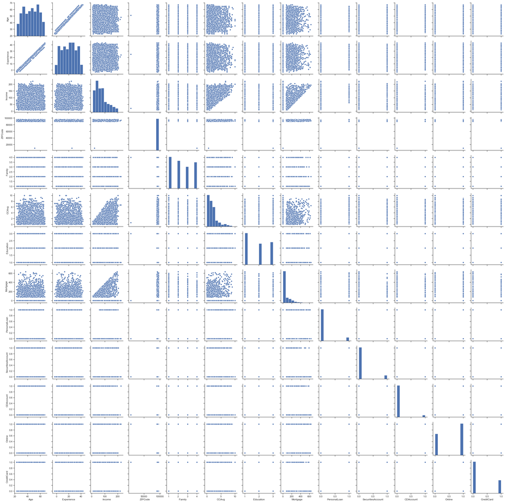

```python
sns.pairplot(data.iloc[:,1:])
```

Age feature is normally distributed with majority of customers falling between 30 years and 60 years of age. We can confirm this by looking at the describe statement above, which shows mean is almost equal to median

CCAvg is also a positively skewed variable and average spending is between 0K to 10K and majority spends less than 2.5K

Mortgage 70% of the individuals have a mortgage of less than 40K. However the max value is 635K

The variables family and education are ordinal variables. The distribution of families is evenly distributed.

```python
# there are 52 records with negative experience. Before proceeding any further we need to clean the same
data[data['Experience'] < 0]['Experience'].count()
```

```
52
```

```python
data.iloc[89,:]
```

```
ID                      90.0
Age                     25.0
Experience              -1.0
Income                 113.0
ZIPCode              94303.0
Family                   4.0
CCAvg                    2.3
Education                3.0
Mortgage                 0.0
PersonalLoan             0.0
SecuritiesAccount        0.0
CDAccount                0.0
Online                   0.0
CreditCard               1.0
Name: 89, dtype: float64
```

```python
#clean the negative variable
dfExp = data.loc[data['Experience'] >0]
negExp = data.Experience < 0
column_name = 'Experience'
mylist = data.loc[negExp]['ID'].tolist() # getting the customer ID who has negative experience
mylist
```

```
[90,
 227,
 316,
 452,
 525,
 537,
 541,
 577,
 584,
 598,
 650,
 671,
 687,
 794,
 890,
 910,
 1174,
 1429,
 1523,
 1906,
 2103,
 2431,
 2467,
 2546,
 2619,
 2718,
 2849,
 2877,
 2963,
 2981,
 3077,
 3131,
 3158,
 3280,
 3285,
 3293,
 3395,
 3426,
 3627,
 3797,
 3825,
 3888,
 3947,
 4016,
 4089,
 4117,
 4286,
 4412,
 4482,
 4515,
 4583,
 4958]
```

**Replace negative experience**

For the record with the ID, get the value of Age column

For the record with the ID, get the value of Education column

Filter the records matching the above criteria from the data frame which has records with positive experience and take the median

Apply the median back to the location which had negative experience

```python
for id in mylist:
    age = data.loc[np.where(data['ID']==id)]["Age"].tolist()[0]
    education = data.loc[np.where(data['ID']==id)]["Education"].tolist()[0]
    df_filtered = dfExp[(dfExp.Age == age) & (dfExp.Education == education)]
    exp = df_filtered['Experience'].median()
    data.loc[data.loc[np.where(data['ID']==id)].index, 'Experience'] = exp
```

```python
data[data['Experience'] < 0]['Experience'].count()
```

```
0
```

```python
data.describe().transpose()
```

|  | count | mean | std | min | 25% | 50% | 75% | max |
| --- | --- | --- | --- | --- | --- | --- | --- | --- |
| ID | 5000.0 | 2500.500000 | 1443.520003 | 1.0 | 1250.75 | 2500.5 | 3750.25 | 5000.0 |
| Age | 5000.0 | 45.338400 | 11.463166 | 23.0 | 35.00 | 45.0 | 55.00 | 67.0 |
| Experience | 4971.0 | 20.243211 | 11.359189 | 0.0 | 10.00 | 20.0 | 30.00 | 43.0 |
| Income | 5000.0 | 73.774200 | 46.033729 | 8.0 | 39.00 | 64.0 | 98.00 | 224.0 |
| ZIPCode | 5000.0 | 93152.503000 | 2121.852197 | 9307.0 | 91911.00 | 93437.0 | 94608.00 | 96651.0 |
| Family | 5000.0 | 2.396400 | 1.147663 | 1.0 | 1.00 | 2.0 | 3.00 | 4.0 |
| CCAvg | 5000.0 | 1.937938 | 1.747659 | 0.0 | 0.70 | 1.5 | 2.50 | 10.0 |
| Education | 5000.0 | 1.881000 | 0.839869 | 1.0 | 1.00 | 2.0 | 3.00 | 3.0 |
| Mortgage | 5000.0 | 56.498800 | 101.713802 | 0.0 | 0.00 | 0.0 | 101.00 | 635.0 |
| PersonalLoan | 5000.0 | 0.096000 | 0.294621 | 0.0 | 0.00 | 0.0 | 0.00 | 1.0 |
| SecuritiesAccount | 5000.0 | 0.104400 | 0.305809 | 0.0 | 0.00 | 0.0 | 0.00 | 1.0 |
| CDAccount | 5000.0 | 0.060400 | 0.238250 | 0.0 | 0.00 | 0.0 | 0.00 | 1.0 |
| Online | 5000.0 | 0.596800 | 0.490589 | 0.0 | 0.00 | 1.0 | 1.00 | 1.0 |
| CreditCard | 5000.0 | 0.294000 | 0.455637 | 0.0 | 0.00 | 0.0 | 1.00 | 1.0 |

**Influence of income and education on personal loan**

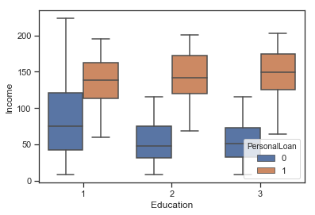

```python
sns.boxplot(x='Education',y='Income',hue='PersonalLoan',data=data)
```

**Observation :** It seems the customers whose education level is 1 is having more income. However customers who has taken the personal loan have the same income levels

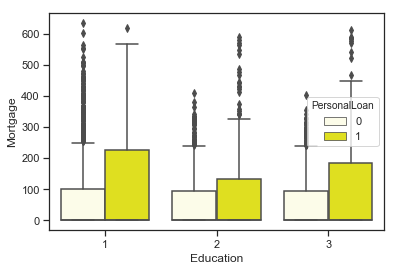

```python
sns.boxplot(x="Education", y='Mortgage', hue="PersonalLoan", data=data,color='yellow')
```

**Inference :** From the above chart it seems that both customers who do not have personal loan and customers who have personal loan have high mortgage

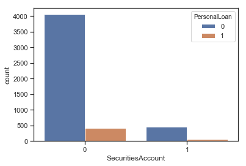

```python
sns.countplot(x="SecuritiesAccount", data=data,hue="PersonalLoan")
```

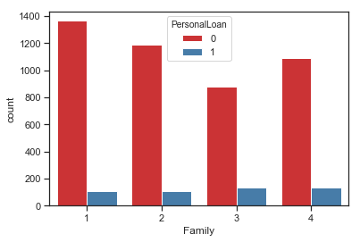

```python
sns.countplot(x='Family',data=data,hue='PersonalLoan',palette='Set1')
```

**Observation:** Family size does not have any impact in personal loan. But it seems families with size of 3 are more likely to take loan. When considering future campaign this might be good association.

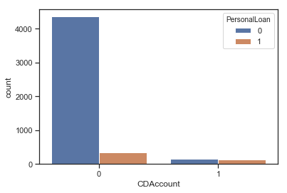

```python
sns.countplot(x='CDAccount',data=data,hue='PersonalLoan')
```

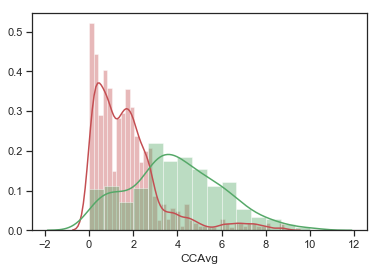

```python
sns.distplot(data[data.PersonalLoan == 0]['CCAvg'], color = 'r')
sns.distplot( data[data.PersonalLoan == 1]['CCAvg'], color = 'g')
```

**Observation:** The graph show persons who have personal loan have a higher credit card average.

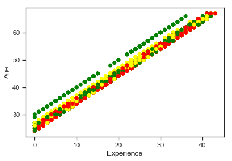

```python
fig, ax = plot.subplots()
colors = {1:'red',2:'yellow',3:'green'}
ax.scatter(data['Experience'],data['Age'],c=data['Education'].apply(lambda x:colors[x]))
plot.xlabel('Experience')
plot.ylabel('Age')
```

**Observation** The above plot show with experience and age have a positive correlation. As experience increase age also increases. Also the colors show the education level. There is gap in the mid forties of age and also more people in the under graduate level

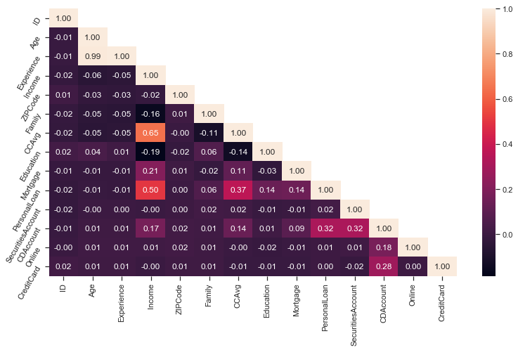

```python
# Correlation with heat map
import matplotlib.pyplot as plt
import seaborn as sns
corr = data.corr()
sns.set_context("notebook", font_scale=1.0, rc={"lines.linewidth": 2.5})
plt.figure(figsize=(13,7))
# create a mask so we only see the correlation values once
mask = np.zeros_like(corr)
mask[np.triu_indices_from(mask, 1)] = True
a = sns.heatmap(corr,mask=mask, annot=True, fmt='.2f')
rotx = a.set_xticklabels(a.get_xticklabels(), rotation=90)
roty = a.set_yticklabels(a.get_yticklabels(), rotation=60)
```

**Observation**

Income and CCAvg is moderately correlated.

Age and Experience is highly correlated

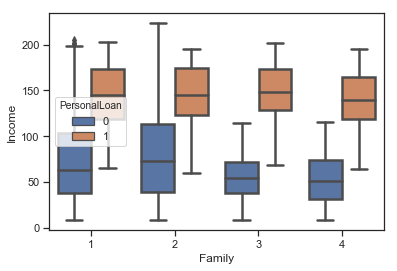

```python
sns.boxplot(x=data.Family,y=data.Income , hue=data.PersonalLoan)
```

**Applying models**

Split data into train and test

```python
from sklearn.model_selection import train_test_split
train_set, test_set = train_test_split(data.drop(['ID','Experience'], axis=1), test_size=0.3 , random_state=100)
```

```python
train_labels = train_set.pop('PersonalLoan')
test_labels = test_set.pop('PersonalLoan')
```

**Naive Bayes**

```python
from sklearn.naive_bayes import GaussianNB
naive_model = GaussianNB()
naive_model.fit(train_set, train_labels)

prediction = naive_model.predict(test_set)
naive_model.score(test_set,test_labels)
```

```
0.8866666666666667
```

**KNN ( K - Nearest Neighbour )**

```python
train_set_indep = data.drop(['Experience' ,'ID'] , axis = 1).drop(labels= "PersonalLoan" , axis = 1)
train_set_dep = data["PersonalLoan"]
X = np.array(train_set_indep)
Y = np.array(train_set_dep)
X_Train = X[ :3500, :]
X_Test = X[3501: , :]
Y_Train = Y[:3500, ]
Y_Test = Y[3501:, ]
```

```python
knn = KNeighborsClassifier(n_neighbors= 21 , weights = 'distance', metric='euclidean')
knn.fit(X_Train, Y_Train)
predicted = knn.predict(X_Test)

acc = accuracy_score(Y_Test, predicted)
print(metrics.confusion_matrix(Y_Test, predicted))
print(acc)
```

```
[[1351   22]
 [ 117    9]]
0.9072715143428952
```

```python
train_set_indep = data.drop(['Experience' ,'ID'] , axis = 1).drop(labels= "PersonalLoan" , axis = 1)
train_set_dep = data["PersonalLoan"]
X = np.array(train_set_indep)
Y = np.array(train_set_dep)
test_size = 0.30 # taking 70:30 training and test set
seed =1 # Random numbmer seeding for reapeatability of the code
X_train, X_test, y_train, y_test = train_test_split(X, Y, test_size=test_size, random_state=seed)
```

```python
# Fit the model on 30%
model = LogisticRegression(solver='lbfgs',class_weight='balanced')
model.fit(X_train, y_train)
y_predict = model.predict(X_test)

model_score = model.score(X_test, y_test)
print(model_score)
print(metrics.confusion_matrix(y_test, y_predict))
```

```
0.8406666666666667
[[1133  218]
 [  21  128]]
```

```python
# Fit the model on 30%
model = svm.SVC(gamma='scale', kernel='rbf',C=1.0)
model.fit(X_train, y_train)
y_predict = model.predict(X_test)

model_score = model.score(X_test, y_test)
print(model_score)
print(metrics.confusion_matrix(y_test, y_predict))
```

```
0.9006666666666666
[[1351    0]
 [ 149    0]]
```

**Model Comparison**

```python
X=data.drop(['PersonalLoan','Experience','ID'],axis=1)
y=data.pop('PersonalLoan')
```

```
KNN: 0.899404 (0.014045)
NB: 0.885798 (0.014654)
```

```
LR: 0.857409 (0.014056)
SVM: 0.904009 (0.013444)
```

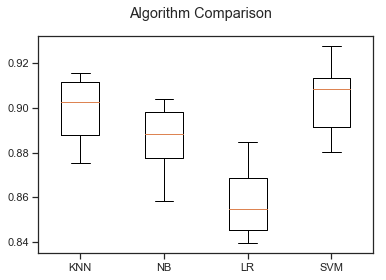

```python
models = []
models.append(('KNN', KNeighborsClassifier(n_neighbors= 15 , weights = 'uniform', metric='euclidean')))
models.append(('NB', GaussianNB()))
models.append(('LR',LogisticRegression(class_weight='balanced',solver='lbfgs')))
models.append(('SVM', svm.SVC(gamma='scale', kernel='rbf',C=1.0)))

# evaluate each model in turn
results = []
names = []
scoring = 'accuracy'
for name, model in models:
	kfold = model_selection.KFold(n_splits=12, random_state=9000)
	cv_results = model_selection.cross_val_score(model, X, y, cv=kfold, scoring=scoring)
	results.append(cv_results)
	names.append(name)
	msg = "%s: %f (%f)" % (name, cv_results.mean(), cv_results.std())
	print(msg)
# boxplot algorithm comparison
fig = plt.figure()
fig.suptitle('Algorithm Comparison')
ax = fig.add_subplot(111)
plt.boxplot(results)
ax.set_xticklabels(names)
plt.show()
```

```
KNN : 0.895333 (0.323522)
NB : 0.890000 (0.331662)
LR : 0.842667 (0.396653)
SVM : 0.899333 (0.317280)
```

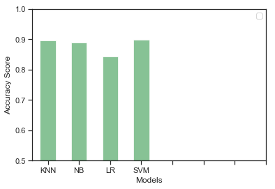

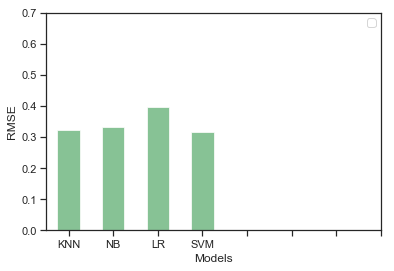

```python
result = []
accuracy = []
rmse = []
names = []
for name, model in models:
    xtrain,xtest,ytrain,ytest = train_test_split(X,y, test_size=0.3, random_state=3)
    model.fit(xtrain,ytrain)
    mod_pred = model.predict(xtest)
    accu = accuracy_score(ytest,mod_pred)
    error = np.sqrt(mean_squared_error(ytest,mod_pred))
    accuracy.append(accu)
    rmse.append(error)
    names.append(name)
    a = pd.DataFrame(accuracy)
    b = pd.DataFrame(rmse)
    print("%s : %f (%f)" %(name, accu,error))
#plot - accuracy
plt.figure(figsize=[7,4])
a.plot(kind='bar', alpha=0.7, color='g', rot=0)
plt.xticks([0,1,2,3,4,5,6,7], names)
plt.ylim(0.5,1)
plt.xlabel('Models')
plt.ylabel("Accuracy Score")
plt.legend("")
plt.show()

#plot - RMSE
plt.figure(figsize=[7,4])
b.plot(kind='bar', alpha=0.7, color='g', rot=0)
plt.xticks([0,1,2,3,4,5,6,7], names)
plt.ylim(0,0.7)
plt.xlabel('Models')
plt.ylabel("RMSE")
plt.legend("")
plt.show()
```

**Conclusion**

The aim of the universal bank is to convert there liability customers into loan customers. They want to set up a new marketing campaign; hence, they need information about the connection between the variables given in the data. Four classification algorithms were used in this study. From the above graph , it seems like **SVM** have the highest accuracy with both KFold method and train test split method and also it has the lowest root mean squared error. So we can choose that(**SVM**) as our final model.